# 언어심리학을 위한 데이터 사이언스 5주차: 데이터 사이언스 #3 (데이터 시각화)

## (9) 척도(scale)

- 정의: 데이터 관찰값을 시각적 자질로 변환하는 방식에 대한 디테일을 정의해주는 함수.
- 기능: x축과 y축의 척도를 원하는 대로 정의할 수 있음.
- 예시
  - x축 데이터가 연속변수일 경우 `scale_x_continuous`, y축 데이터가 연속변수일 경우 `scale_y_continuous`를 사용할 수 있음.
  - `trans` 논항을 통해 x/y축 데이터 관찰값을 다양한 척도로 변환할 수 있음. 가령, 관찰값 수치가 너무 크거나 데이터가 정규분포를 이루지 않을 경우 log화된 척도를 사용할 수 있음.

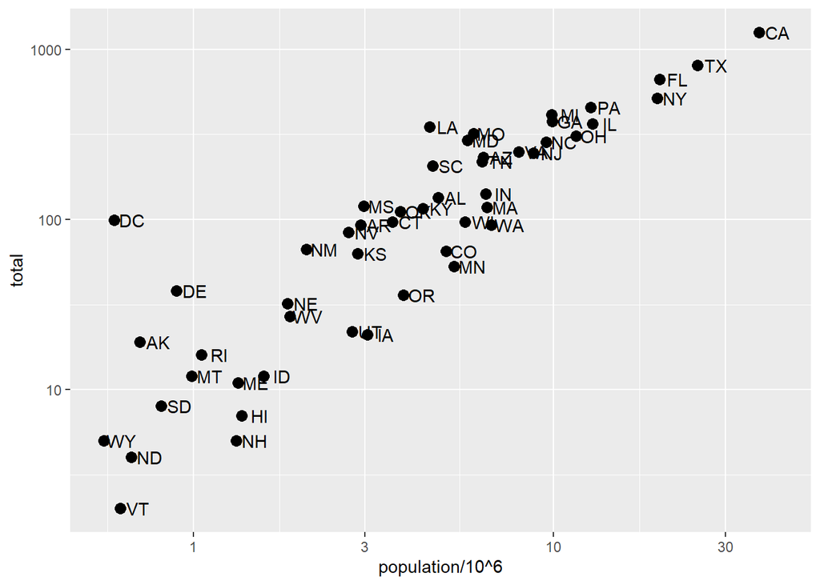

```r
# x축과 y축 척도를 밑이 10인 로그값으로 변환하기.
p + geom_point(size = 3) +
  geom_text(nudge_x = 0.05) + # 로그 척도로 변환되었으므로 포인트-레이블의 간격을 줄여야 함.
  scale_x_continuous(trans = "log10") +
  scale_y_continuous(trans = "log10")
```

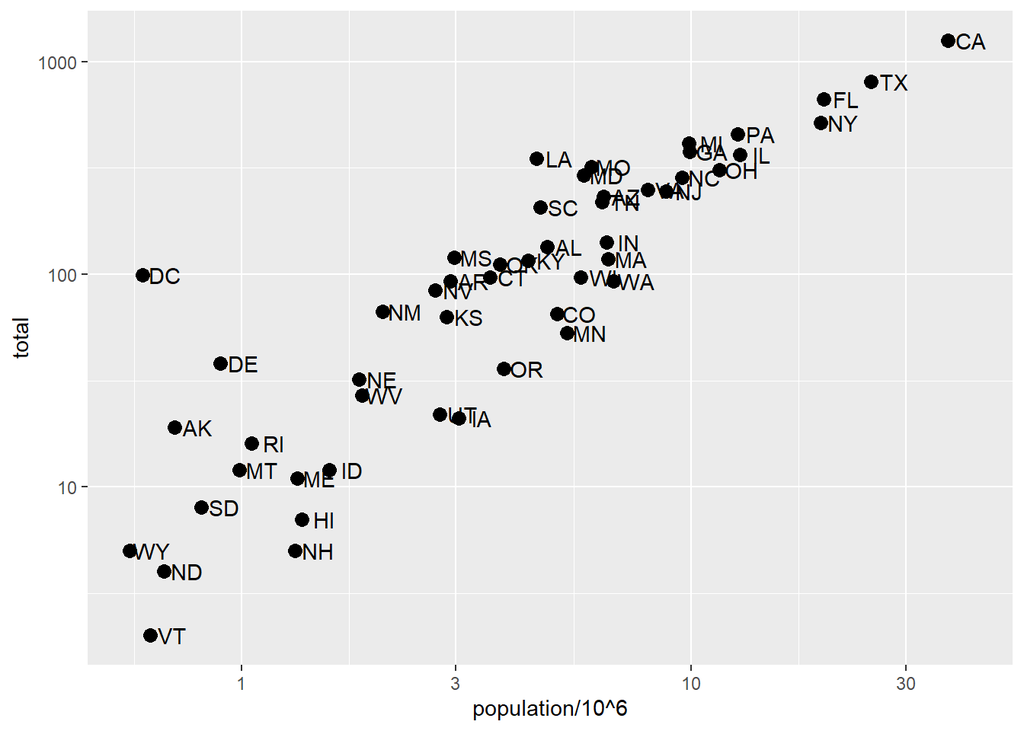

```r
# 아래의 코드도 위의 코드와 동일한 결과를 보여줌.
p + geom_point(size = 3) +
  geom_text(nudge_x = 0.05) +
  scale_x_log10() + # x축 척도를 밑이 10인 로그값으로 변환하기.
  scale_y_log10() # y축 척도를 밑이 10인 로그값으로 변환하기.
```

## (10) 축 이름 및 플롯 제목 생성하기

- 축 이름 생성: x축 이름 변경/생성은 `xlab()`, y축 이름 변경/생성은 `ylab()` 함수 사용.
- 플롯 제목 생성: 플롯 제목 생성은 `ggtitle()` 함수 사용.

```r
# 플롯에 원하는 한글 서체 적용하기: windowsFonts 함수 사용하기.
Sys.setlocale("LC_COLLATE", "ko_KR.UTF-8") # R에서 한글 입력 시 깨지는 현상 방지하기.
```

```
## [1] ""
```

```r
windowsFonts(NanumGothic = windowsFont("나눔 고딕")) # 원하는 한글 서체 적용하기.
```

```r
# 플롯에 원하는 한글 서체 적용하기: showtext 패키지 사용하기.
library(showtext)
library(sysfonts)

font_add_google("Noto Serif KR", "Noto Serif KR") # google 폰트 사이트에서 직접 폰트 로딩하기.
showtext_auto()

font_add("KoPub", "C:/Windows/Fonts/KoPubWorld Dotum_Pro Bold.otf") # 내 컴퓨터에 설치된 폰트 로딩하기.
showtext_auto()
```

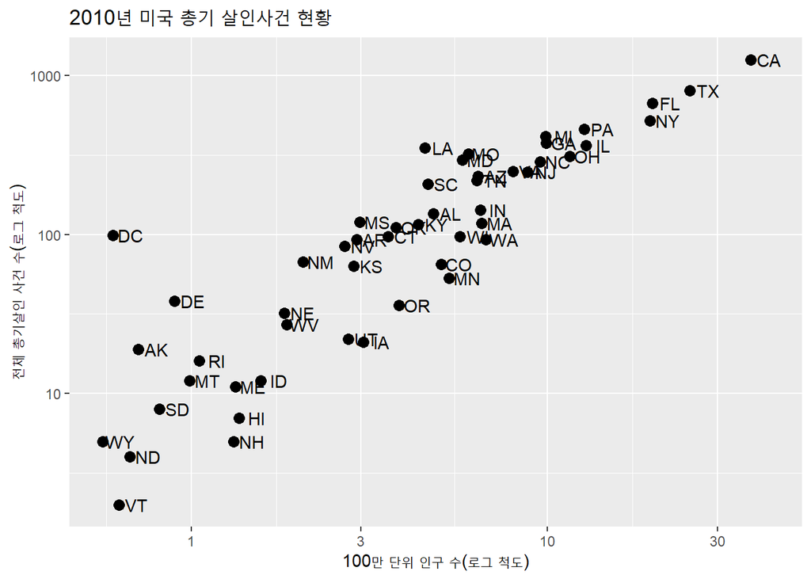

```r
# 플롯의 축 이름 변경 및 플롯 제목 추가하기.
p + geom_point(size = 3) +
  geom_text(nudge_x = 0.05) +
  scale_x_log10() +
  scale_y_log10() +
  xlab("100만 단위 인구 수(로그 척도)") +
  ylab("전체 총기살인 사건 수(로그 척도)") +
  ggtitle("2010년 미국 총기 살인사건 현황")
```